# Analisi dei dati relativi ai risultati dell’ Eurovision song contest

Campo Lorenzo

2022-07-01

# Cos’è l’Eurovision song contest?

L’eurovision song copntest è un concorso musicale a livello internazionale che si svolge ogni anno nel mese di Maggio.

Fondato dai Big 5 nel 1956, è il concorso musicale piu longevo al mondo

I Big 5 o grandi 5 sono i 5 stati fondatori degli eurovision e sono Regno Unito, Spagna, Francia, Germania e Italia. Lo status di Big 5 garantisce la qualifica istantanea alle finali. Per questo motivo le nostre analisi si concentrerenno principalmente sui risultati delle finali poiche in caso contrario, stati che hanno partecipato alle semifinali si ritroverebbero con piu punti di quanti gli spetterebbero

Lo stato ospitante è lo stato che ha ottenuto la vittoria l’anno precedente

### Come avviene la votazione?

La valutazione delle canzoni viene divisa tra giuria e televoto. Ogni stato assegna voti alle 10 canzoni piu piaciute in base alla classifica stillata dal televoto e dalla giuria della propria nazione in modo separato. Ogni nazione NON può votare per se stessa I punti assegnati a ogni canzone sono assegnati in questo modo

- primo posto:12 punti
- secondo posto 10 punti
- terzo posto in poi: da 8 a 1 punto

Il massimo punteggio complessivo è di 24 per ogni stato votante meno il proprio

Si noti che questo sistema di votazione è relativa mente recente (introdotto nel 2016). Eurovision ha cambiato molto spesso i suoi sistemi di votazione e, come vedremo in seguito, ciò influirà sull’analisi dei dati.

Ora che abbiamo capito di cosa stiamo parlando possiamo cominciare l’analisi

# Librerie e importazione del dataset

Cominciamo con l’importare le librerie che ci serviranno per la nostra analisi

```r
#http://www.escstats.com/ fonte dei dati
#https://data.world/rhubarbarosa/eurovisionvotingstats Download dataset

library("dplyr")
library("readr")
library(tidyr)
library(ggplot2)
library(purrr)
library(broom)
library(stringr)
library(modelr)

options(scipen = 999) #ci serve ad eliminare la notazione scientifica
```

Importiamo ora 2 dei dataset che useremo durante la nostra analisi - events_data: contiene i dati generali dell’evento e sarà la base della maggior parte dei nostri data frame. - event_televote: contiene dati dettagliati delle votazioni dal 2016 al 2018 con i dettagli della votazione di giuria e televoto e relativi piazzamenti in classifica -event_country_votes: mostra stati votanti e stati riceventi per ogni votazione della giuria

Il nostro dataset contiene dati a partire dalla prima edizione del 1956 fino al 2019 ma la prima edizione, poiché in quell’occasione il sistema di votazione non dichiarava il punteggio finale, verrà ignorato in quanto non contiene dati utili ai nostri scopi e potrebbe influire sui risultati di certi grafici

Inoltre il 2019 è presente solo in un dataset ma, poiche non cotiene dati che possono gravemente influenzare gli esiti dei nostri esami, ho ritenuto opportuno tenerlo in quanto idoneo nel contesto preso in considerazione

```r
events_data <- read_delim("E:/dataset eurovision/EventParticipantsAndPlace.csv", delim = ";", escape_double = FALSE, trim_ws = TRUE)
events_data=events_data%>%
  mutate(Country=replace(Country,Country=="Itali","Italy"))%>%
  mutate(Country=replace(Country,Country=="Sqitzerland","Switzerland"))%>%
  arrange(event.year)%>%
  filter(event.year>1956)

event_televote<-read_delim("E:/dataset eurovision/VotingDetails.csv", delim = ";", escape_double = FALSE, trim_ws = TRUE)


event_country_vote<-read_delim("E:/dataset eurovision/CountryVotes.csv", delim = ";", escape_double = FALSE, trim_ws = TRUE)

state_votes<-event_country_vote%>%
  filter(event.type=="final" | event.type=="grand-final")%>%
  select(event.year,awarding.country,recipient.country,pts)
```

# Tabelle di supporto

Creiamo ora 2 tabelle che ci serviranno piu avanti Queste tabelle sono: - edition_max_votes: fornisce il massimo punteggio attribuito da uno stato a un altro in base all’edizione - support:contiene il numero di partecipanti in ogni edizione.

```r
event.year=c(1957:2018)
i=0
max_points=rep(0,length(event.year))
for (var in event.year) {
  i=i+1
  x=0
  if(var<=1961)
  {
    x=10
  }
  else
  if(var==1962)
  {
    x=3
  }
  else
  if(var>=1963 & var<=1966)
  {
    x=5
  }
  else
  if(var>=1967 & var<=1973)
  {
    x=10
  }
  else
  if(var==1974)
  {
    x=10
  }
  else
  if(var>=1975 & var<=2015)
  {
    x=12
  }
  else
  if(var>=2016 & var<=2022)
  {
    x=24
  }
  max_points[i]=x
}

edition_max_votes<-data.frame(event.year,max_points)
support=events_data%>%
  filter(event.year>1956)%>%
  group_by(event.year)%>%
  summarize(partecipanti=n_distinct(Country))
```

# statistiche interessanti

Possiamo ora cominciare a rispondere ad alcune delle nostre domande

### Quali canzoni hanno ricevuto piu voti?

Quali sono state le canzoni piu votate nella storia del festival? Ci limitiamo ad analizzare i dati a partire dal 2016 poiché, come spiegato in precedenza, coincide con l’entrata in vigore del nuovo sistema di punteggio e i dati delle edizioni precedenti non sono sufficienti a elaborare una conversione accurata.

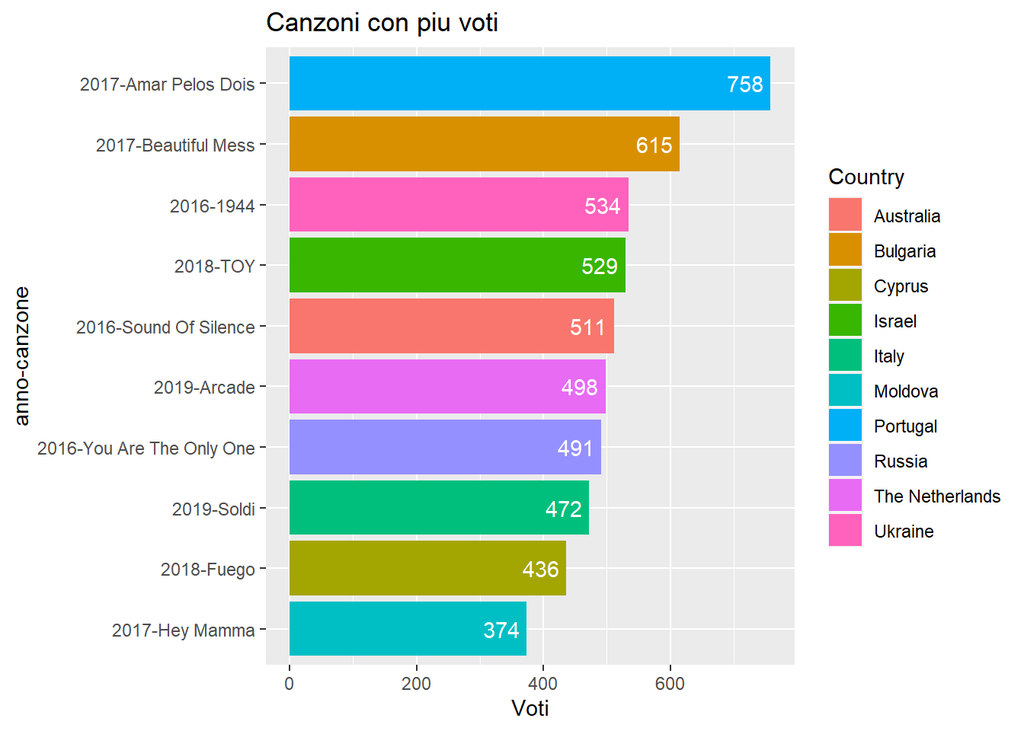

```r
most_voted_songs<-events_data%>%
  filter(event.type=="final" | event.type=="grand-final",event.year>=2016)%>%
  mutate(Entry=paste(event.year,Song))%>%
  select(Entry,Country,pts)%>%arrange(-pts)



ggplot(head(most_voted_songs,10),mapping=aes(y=reorder(str_replace(string=Entry,pattern="[^[:graph:]]",replacement = "-"),pts), x=pts,fill=Country))+
  geom_col()+
  labs(title="Canzoni con piu voti",
        x="Voti", y= "anno-canzone")+
  geom_text(aes(label = pts),nudge_x = -40, color="white")
```

Congratulazioni a Amar Pelos Dois, canzone del portogallo del 2017, per essere la canzone piu apprezzata nella storia recente degli eurovision

“Perche non valutare la percentuale di punti ricevuti sul totale possibile? In questo modo si potrebbero valutare anche le edizioni precedenti”

Semplice, perche non conosciamo quanti hanno votato e quanti di questi voti siano leggittimi(sono sorti spesso casi di voti concordati, 5 solo quest anno), ma solo il totale.

### Quale nazione Ha totalizzato piu vittorie?

Un conto è ricevere un buon punteggio, ma un altro è ottenere l’agoniato premio. Vediamo ora chi è stato lo stato biu abile

```r
most_victory<-events_data%>%filter(event.type=="final" | event.type=="grand-final",Place==1)%>%group_by(Country)%>%summarise(vittorie=n())%>%arrange(-vittorie)
most_victory
```

```
## # A tibble: 27 x 2
##    Country         vittorie
##    <chr>              <int>
##  1 Ireland                7
##  2 Sweden                 6
##  3 France                 5
##  4 Luxembourg             5
##  5 The Netherlands        5
##  6 United Kingdom         5
##  7 Israel                 4
##  8 Denmark                3
##  9 Norway                 3
## 10 Austria                2
## # ... with 17 more rows
```

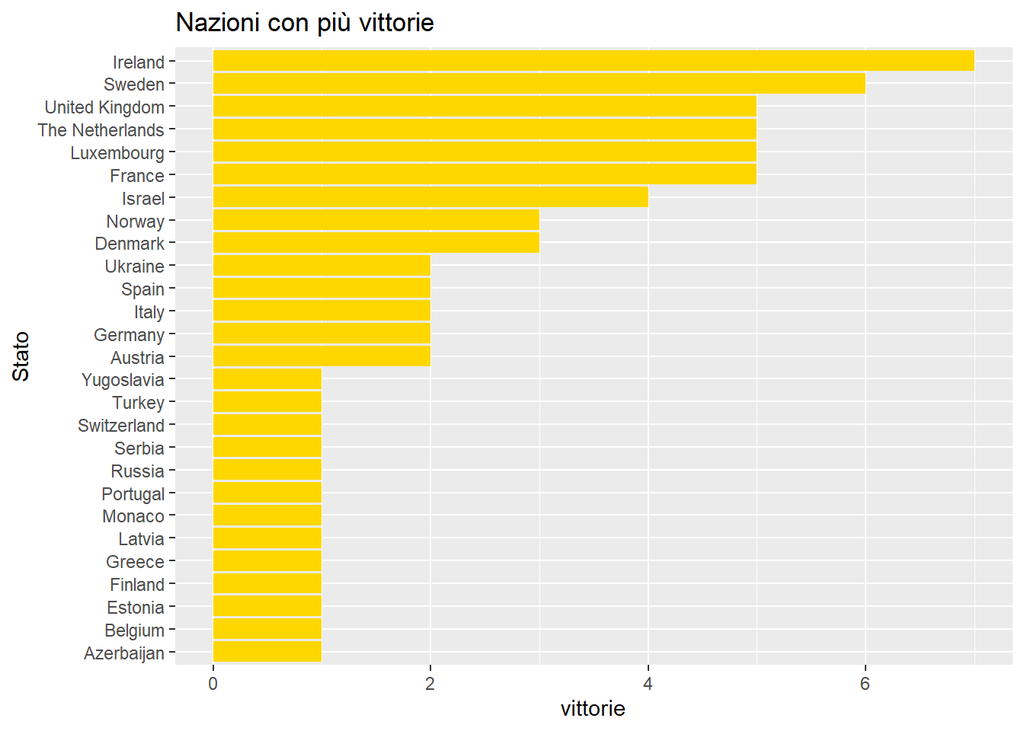

```r
ggplot(data=most_victory ,mapping=aes(y= reorder(Country,vittorie),x=vittorie))+
  geom_col(fill="#ffd700")+
  labs(title="Nazioni con più vittorie",
        x="vittorie", y= "Stato")
```

### Quale nazione ha totalizzato piu ultime posizioni?

Passiamo ora dalla parte opposta della classifica

Chi ha totalizzato piu ultime posizioni?

```r
Finalists<-events_data%>%
  filter(event.type=="final" | event.type=="grand-final")%>%
  select(event.year,Place)%>%group_by(event.year)%>%summarise(finalisti=max(Place))

most_last<- inner_join(events_data,Finalists)%>%filter(event.type=="final" | event.type=="grand-final",Place==finalisti)%>%group_by(Country)%>%summarise(ultimi=n())%>%arrange(-ultimi)
sum(most_last[2])
```

```
## [1] 87
```

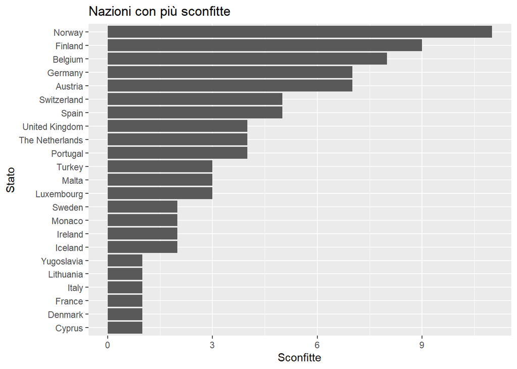

```r
ggplot(data=most_last ,mapping=aes(y= reorder(Country,ultimi),x=ultimi))+
  geom_col()+
  labs(title="Nazioni con più sconfitte",
        x="Sconfitte", y= "Stato")
```

### Quale la nazione ha collezionato piu seconde posizioni?

Non sempre il primo classificato ottiene tutta la gloria Spesso i “runner up” o secondi classificati acquisiscono piu successo dei loro colleghi al primo posto e spesso appaiono nuovamente in edizioni successive del festival stesso.

Vediamo chi è quasi arrivato alla vetta

```r
most_second<-events_data%>%filter(event.type=="final" | event.type=="grand-final",Place==2)%>%arrange(Country)%>%group_by(Country)%>%summarise(runner_up=n())%>%arrange(-runner_up)
most_second
```

```
## # A tibble: 25 x 2
##    Country        runner_up
##    <chr>              <int>
##  1 United Kingdom        15
##  2 France                 4
##  3 Germany                4
##  4 Ireland                4
##  5 Russia                 4
##  6 Spain                  4
##  7 Italy                  3
##  8 Switzerland            3
##  9 Belgium                2
## 10 Iceland                2
## # ... with 15 more rows
```

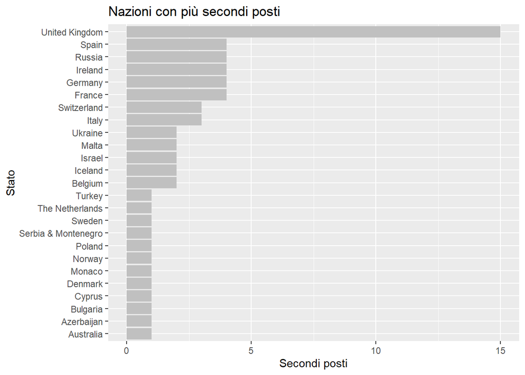

```r
ggplot(data=most_second ,mapping=aes(y= reorder(Country,runner_up),x=runner_up))+
  geom_col(fill="#c0c0c0")+
  labs(title="Nazioni con più secondi posti",
        x="Secondi posti", y= "Stato")
```

### Quali sono gli stati che hanno guadagnato piu punti, quanti di questi sono stati attribuiti dal televoto e quanti dalla giuria?

Ora facciamo un piccolo confronto vediamo ora rappresentato quanto hanno contribuito televoto e giuria nelle votazioni dei vari stati.

```r
piramid_j<-event_televote%>%filter(event.type=="final" | event.type=="grand-final")                                     %>%select(event.year,Receiving.country,Jury.points,Total.pts)%>%mutate(type="Jury")
names(piramid_j)[names(piramid_j) == 'Jury.points'] <- 'pts'

piramid_t<-event_televote%>%filter(event.type=="final" | event.type=="grand-final")                                     %>%select(event.year,Receiving.country,Televoting.points,Total.pts)%>%mutate(type="Televote",)
names(piramid_t)[names(piramid_t) == 'Televoting.points'] <- 'pts'

piramid_jt<-full_join(piramid_j,piramid_t)%>%
  group_by(Receiving.country,type)%>%
  summarise(pts=sum(pts,na.rm = TRUE),Total.pts=sum(Total.pts,na.rm = TRUE))%>%
  mutate(pts=ifelse(type=="Jury", pts*(-1), pts*1))%>%arrange(-Total.pts)
```

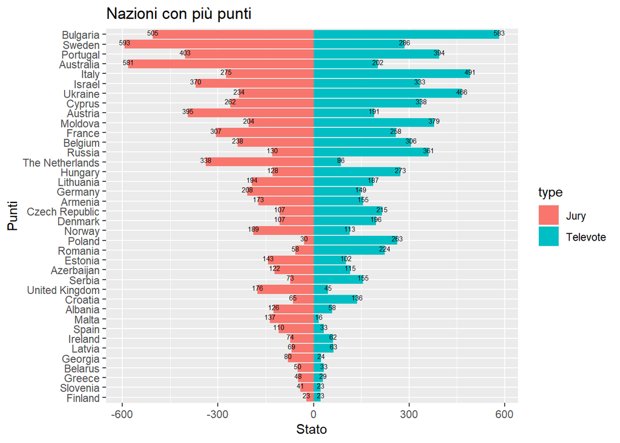

```r
    ggplot(piramid_jt,aes(x =  reorder(Receiving.country,Total.pts),y = pts,fill=type)) +
    geom_col() +
    coord_flip()+
    labs(title="Nazioni con più punti",
        x="Punti", y= "Stato")+
    geom_text(size=2,aes(label = abs(pts)),nudge_x = 0.2, color="black")
```

Vediamo che esistono alcuni casi poco bilanciati come la Polonia e Regno Unito

La polonia deve il suo successo al televoto mentre, al contrario, il regno unito lo deve alla giuria

### Qual’è la posizione media ottenuta da ogni stato?

Vediamo infine la media complessiva dei piazzamenti dei vari stati

```r
media_pos<-events_data%>%filter(event.type=="final" | event.type=="grand-final")%>%group_by(Country)%>%summarise(media.Place=mean(Place,na.rm=TRUE))%>%arrange(media.Place)
knitr::kable(media_pos,
 caption = "Media posizione in classifica")
```

Media posizione in classifica

| Country | media.Place |
| --- | --- |
| Serbia & Montenegro | 4.500000 |
| Bulgaria | 6.250000 |
| Monaco | 7.380952 |
| Italy | 7.568182 |
| Russia | 7.619048 |
| Sweden | 8.379310 |
| Azerbaijan | 8.727273 |
| Ireland | 8.866667 |
| Australia | 9.000000 |
| Ukraine | 9.133333 |
| United Kingdom | 9.193548 |
| Luxembourg | 9.194444 |
| Armenia | 10.000000 |
| Denmark | 10.000000 |
| France | 10.065574 |
| The Netherlands | 10.180000 |
| Switzerland | 10.312500 |
| Israel | 10.361111 |
| Yugoslavia | 10.666667 |
| Estonia | 10.937500 |
| Germany | 11.112903 |
| Serbia | 11.333333 |
| Greece | 11.421053 |
| Belgium | 11.540000 |
| Latvia | 11.600000 |
| Moldova | 11.900000 |
| Norway | 11.909091 |
| Malta | 11.960000 |
| Austria | 12.276596 |
| Croatia | 12.333333 |
| Georgia | 12.428571 |
| Spain | 12.440678 |
| Turkey | 12.636364 |
| Romania | 13.055556 |
| Bosnia & Herzegovina | 13.166667 |
| Cyprus | 13.400000 |
| Albania | 13.666667 |
| Iceland | 13.960000 |
| Czech Republic | 14.000000 |
| Portugal | 14.047619 |
| North Macedonia | 14.444444 |
| Finland | 14.777778 |
| Hungary | 15.071429 |
| Poland | 15.428571 |
| Slovenia | 15.733333 |
| Montenegro | 16.000000 |
| Belarus | 17.166667 |
| Lithuania | 17.307692 |
| Morocco | 18.000000 |
| Slovakia | 19.333333 |
| San Marino | 21.500000 |

Possiamo notare che al primo posto abbiamo Serbia & Montenegro. Sebbene non siano uno stato a se, il regolamento non vieta a 2 stati di unirsi in un unica esibizione.

### Quante partecipazioni alla finale dell’eurovision ha guadagnato ogni stato?

Vediamo ora quante volte ogni stato ha partecipato alla finale

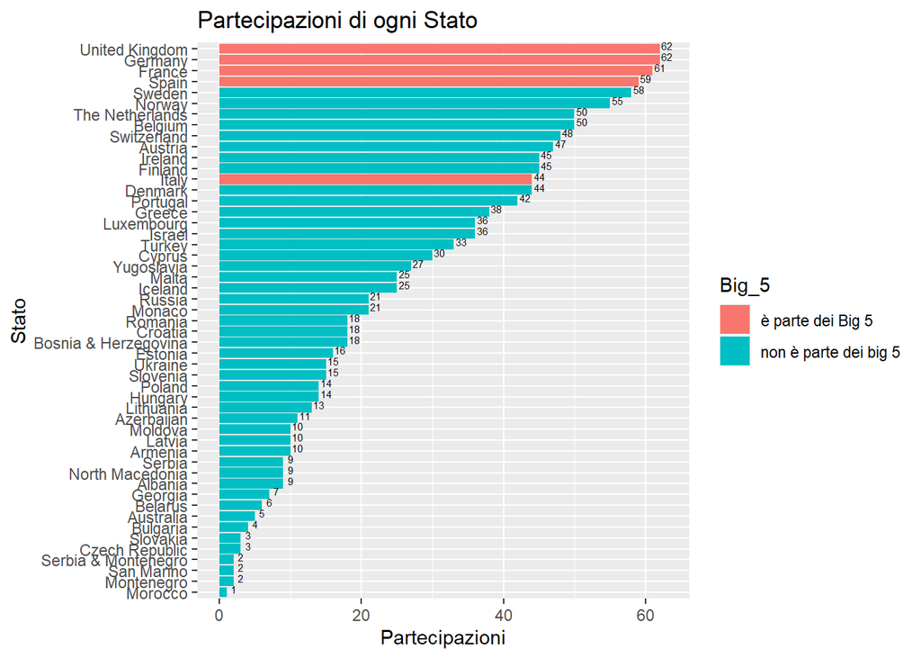

```r
most_partecipation<-events_data%>%filter(event.type=="final" | event.type=="grand-final")%>%
  group_by(Country)%>%summarise(partecipazioni=n())%>%arrange(-partecipazioni)%>%mutate(Big_5=ifelse(Country %in% c("Italy","Germany","United Kingdom","Spain","France"),"è parte dei Big 5","non è parte dei big 5"))


ggplot(data=most_partecipation ,mapping=aes(y= reorder(Country,partecipazioni),x=partecipazioni,fill=Big_5))+
  geom_col()+
  labs(title="Partecipazioni di ogni Stato",
        x="Partecipazioni", y= "Stato")+
  geom_text(size=2,aes(label = partecipazioni),nudge_y = 0.3, nudge_x = 1, color="black")
```

Senza troppe sorprese vediamo 4 dei Big 5 in cima alla classifica(Regno unito,Germania,Francia,Spagna) poichè sono automaticamente inclusi alle finali.

L’italia però fa eccezione

### Perche l’italia non ha partecipato in quantità equivalente?

Troviamo il periodo d’attività dell’Italia

```r
italy_partecipation<-events_data%>%filter(event.type=="final" | event.type=="grand-final",Country=="Italy")%>%
  select(event.year,Country)
italy_partecipation
```

```
## # A tibble: 44 x 2
##    event.year Country
##         <dbl> <chr>
##  1       1957 Italy
##  2       1958 Italy
##  3       1959 Italy
##  4       1960 Italy
##  5       1961 Italy
##  6       1962 Italy
##  7       1963 Italy
##  8       1964 Italy
##  9       1965 Italy
## 10       1966 Italy
## # ... with 34 more rows
```

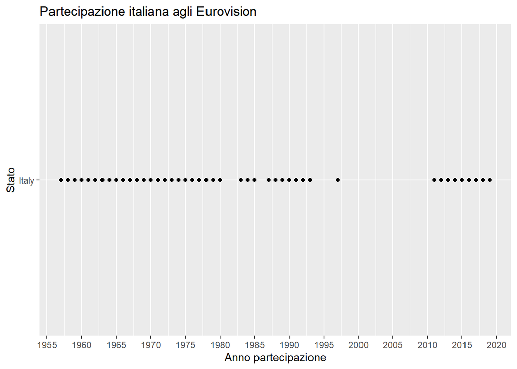

```r
ggplot(data=italy_partecipation ,mapping=aes(x=event.year,y=Country))+
  geom_point()+
  scale_x_continuous(breaks = scales::extended_breaks(n=12))+
  labs(title="Partecipazione italiana agli Eurovision",
        x="Anno partecipazione", y= "Stato")
```

Vediamo chiaramente un periodo relativamente esteso di tempo in cui l’italia si è astenuta dal partecipare.

Il motivo è che a quel tempo l’Eurovision non era abbastanza conosciuto e la RAI, emittente che paga i diritti televisivi all’EBU(European Broadcasting Union, prima conosciuta come eurovision, da cui il nome del concorso), non riteneva questo investimento fruttuoso.

l’Italia è tornata nel 2011 dopo continue richieste da parte degli artisti. Da allora gli ascolti dell’eurovision in Italia sono ai massimi storici, specie dopo la vittoria del 2021.

### I Big 5 meritano il loro posto in finale?

Vediamo se il loro risultato medio merita il posto permanente in finale

```r
Big_5.pos=media_pos%>%filter(Country %in% c("Italy","Germany","United Kingdom","Spain","France"))

knitr::kable(Big_5.pos,
 caption = "Media posizione in classifica dei Big 5")
```

Media posizione in classifica dei Big 5

| Country | media.Place |
| --- | --- |
| Italy | 7.568182 |
| United Kingdom | 9.193548 |
| France | 10.065574 |
| Germany | 11.112903 |
| Spain | 12.440678 |

Possiamo constatare che mediamente la loro posizione è superiore alla metà dei finalisti (25 minimi in base al regolamento)

Considero l’accesso diretto alla finale come guadagnato.

### Quali stati hanno preferenze nel dare i loro 12 punti?

```r
most_voted_country<-event_country_vote%>%filter(event.type=="final" | event.type=="grand-final",pts==12)%>%
  group_by(awarding.country,recipient.country)%>%summarise(count=n())%>%arrange(-count)%>%
  mutate(votante_votato=paste(awarding.country,"-",recipient.country))
most_voted_country
```

```
## # A tibble: 631 x 4
## # Groups:   awarding.country [52]
##    awarding.country recipient.country count votante_votato
##    <chr>            <chr>             <int> <chr>
##  1 Cyprus           Greece               22 Cyprus - Greece
##  2 Greece           Cyprus               16 Greece - Cyprus
##  3 Denmark          Sweden               11 Denmark - Sweden
##  4 Belarus          Russia               10 Belarus - Russia
##  5 Moldova          Romania              10 Moldova - Romania
##  6 Norway           Sweden                9 Norway - Sweden
##  7 Romania          Moldova               9 Romania - Moldova
##  8 Iceland          Denmark               8 Iceland - Denmark
##  9 Spain            Germany               8 Spain - Germany
## 10 Spain            Italy                 8 Spain - Italy
## # ... with 621 more rows
```

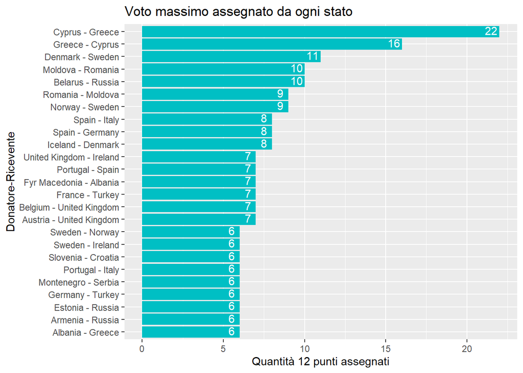

```r
ggplot(data=head(most_voted_country,25) ,mapping=aes(y= reorder(votante_votato,count),x=count))+
  geom_col(fill="#00bfc4")+
  labs(title="Voto massimo assegnato da ogni stato",
        x="Quantità 12 punti assegnati", y= "Donatore-Ricevente")+
  geom_text(aes(label = count),nudge_y = 0.1 , nudge_x = -0.5, color="white")
```

Interessante notare come Grecia e Cipro si siano assegnati a vicenda 12 punti quasi costantemente

Ormai è diventata battuta ricorrente i 12 punti di Cipro e Grecia assegnati sempre l’uno all’altro ogni edizione

### Perche cipro ha ricevuto meno voti da parte della grecia?

Vediamo quante volte hanno partecipato rispettivamente Cipro e Grecia

```r
greece_cyprus<-events_data%>%filter(event.type=="final" | event.type=="grand-final",Country=="Greece" | Country=="Cyprus")%>%
  select(Country)%>%
  arrange(Country)%>%
  group_by(Country)%>%summarise(count=n())

greece_cyprus
```

```
## # A tibble: 2 x 2
##   Country count
##   <chr>   <int>
## 1 Cyprus     30
## 2 Greece     38
```

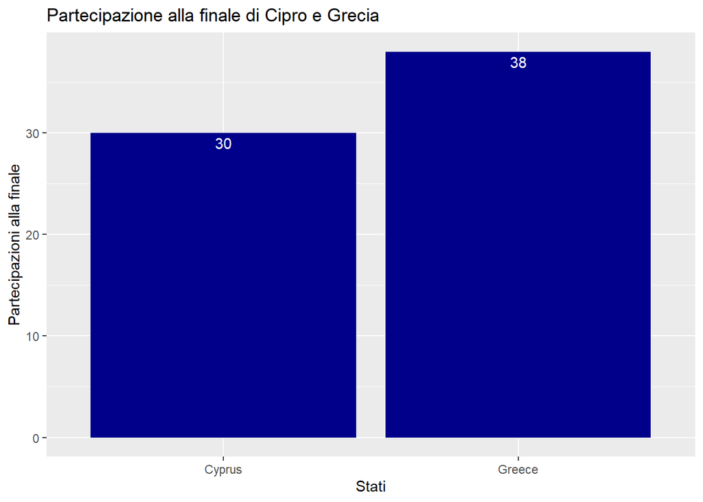

```r
ggplot(data=greece_cyprus ,mapping=aes(x=Country, y=count))+
  geom_col(fill="dark blue")+
  labs(title="Partecipazione alla finale di Cipro e Grecia",
        x="Stati", y= "Partecipazioni alla finale")+
  geom_text(aes(label = count),nudge_y = -1 ,  color="white")
```

Cipro si è qualificato per le finali meno volte della grecia e, poiché uno stato partecipante può ancora votare, da il suo voto alla grecia mentre, la giuria greca, non può fare altrettanto in quanto cipro non è piu parte del concorso.

# Analisi di correlazione tra punti ottenuti e ordine di apparizione

è ora di passare a qualcosa di piu serio, un analisi sulla correttezza dei voti emessi

Spesso sorge spontaneo chiedersi quanto i voti vengano influenzati da fattori esterni e spesso ciò accade dopo che il proprio paese non ha guadagnato l’ambito trofeo

Ma perche analizzare l’ordine di apparizione? Un utente sul social network Reddit ha condiviso questa domanda con la sua opinione:

- Il voto viene influenzato poichè molti telespettatori assistono solo alle esibizioni successive a quella del prorpio rappresentante e non a quelle precedenti. Lo spettatore quindi si fa un idea solo sulle esibizioni che avvengono dopo quella della propria nazione e tende a votarle dando un punteggio maggiore ad esse rispetto alle precedenti.

Ipotesi legittima che adesso andremo a verificare

### L’ordine di esibizione influenza i punti ottenuti totali?

```r
global_votes<-events_data%>%filter(event.type=="final" | event.type=="grand-final",event.year>1956)%>%select(event.year,Country,order.of.appearance,Place,pts)

support=events_data%>%filter(event.year>1956)%>%group_by(event.year)%>%summarize(partecipanti=n_distinct(Country))

global_votes=inner_join(x=global_votes ,y=support)%>%mutate(percent.appearance=100*order.of.appearance/partecipanti)
global_votes=inner_join(global_votes,edition_max_votes)%>%mutate(percent.pts=100*pts/(max_points*(partecipanti-1)))
```

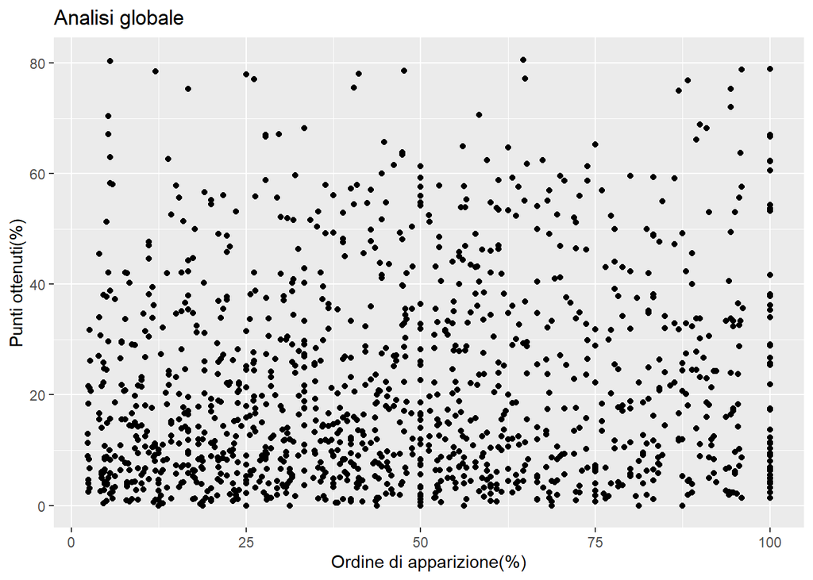

```r
ggplot(global_votes,aes(percent.appearance,percent.pts))+
  geom_point()+
  labs(title="Analisi globale",x="Ordine di apparizione(%)", y= "Punti ottenuti(%)")
```

Da una prima occhiata non sembra eserci una correlazione tra voti e ordine di apparizione, ma per esserne sicuri guardiamo i dati matematici

```r
mod1 = lm(percent.pts ~ percent.appearance, data = global_votes)
summary(mod1)
```

```
##
## Call:
## lm(formula = percent.pts ~ percent.appearance, data = global_votes)
##
## Residuals:
##     Min      1Q  Median      3Q     Max
## -24.626 -14.277  -5.332  10.376  62.040
##
## Coefficients:
##                    Estimate Std. Error t value             Pr(>|t|)
## (Intercept)        17.92685    0.99497   18.02 < 0.0000000000000002 ***
## percent.appearance  0.07656    0.01832    4.18            0.0000312 ***
## ---
## Signif. codes:  0 '***' 0.001 '**' 0.01 '*' 0.05 '.' 0.1 ' ' 1
##
## Residual standard error: 18.05 on 1256 degrees of freedom
##   (24 osservazioni eliminate a causa di valori mancanti)
## Multiple R-squared:  0.01372,    Adjusted R-squared:  0.01293
## F-statistic: 17.47 on 1 and 1256 DF,  p-value: 0.00003118
```

```r
mod1$coefficients
```

```
##        (Intercept) percent.appearance
##        17.92684731         0.07655813
```

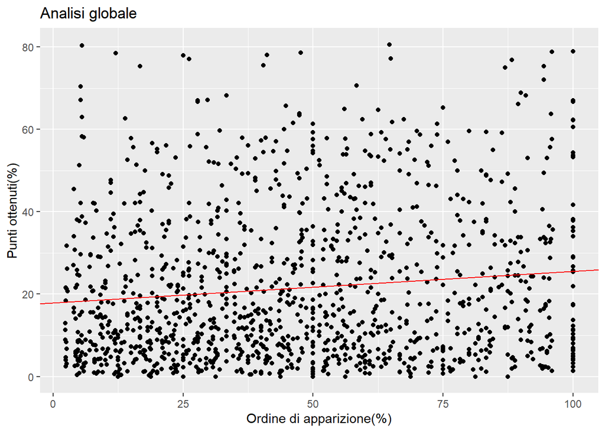

```r
ggplot(global_votes, aes(percent.appearance,percent.pts)) +
  geom_point() +
  geom_abline(intercept = mod1$coefficients[1],
              slope = mod1$coefficients[2],
              color = "red")+
  labs(title="Analisi globale",x="Ordine di apparizione(%)", y= "Punti ottenuti(%)")
```

La retta che mostra la previsione tende ad aumentare leggermente, ma non possiamo parlare ancora di correlazione

Cerchiamo ora R e R^2

```r
r_global = cor(global_votes$percent.appearance, global_votes$percent.pts,use= "complete.obs")
r_global
```

```
## [1] 0.1171318
```

```r
r_global^2
```

```
## [1] 0.01371985
```

Poiché r^2 è molto vicino a 0, una correlazione tra l’ordine di apparizione e i punti ottenuti sembra quindi non esserci.

Considero le due variabili indipendenti

### Ma varrà la stessa cosa per il voto degli spettatori?

ripetiamo lo stesso procedimento ma sta volta usando i dati del televoto

```r
#punti_televoto--------------------------------------------
tele_votes<-event_televote%>%
                         filter(event.type=="grand-final")%>%
                         group_by(event.year,Receiving.country)%>%
                         summarise(pts=sum(Televoting.points,na.rm = TRUE))
tele_votes=inner_join(x=tele_votes , y=global_votes, by=c("event.year"="event.year","Receiving.country"="Country") )

tele_votes=inner_join(x=tele_votes ,y=support)%>%
  mutate(percent.appearance=100*order.of.appearance/partecipanti, percent.voti=100*pts.x/(12*nrow(event_televote%>%select(Awarding.country)%>%group_by(Awarding.country)%>%summarise())))
```

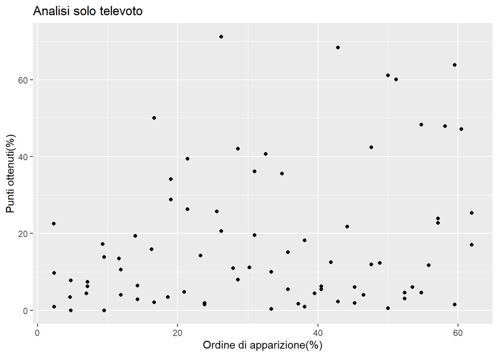

```r
ggplot(tele_votes,aes(percent.appearance,percent.voti))+geom_point()+
  labs(title="Analisi solo televoto", x="Ordine di apparizione(%)", y= "Punti ottenuti(%)")
```

Il grafico sembra già mostrare un certo andamento. Piu ci si sposta a destra piu la percentuale dei voti sale

```r
mod2 = lm(percent.voti ~ percent.appearance, data = tele_votes)
summary(mod2)
```

```
##
## Call:
## lm(formula = percent.voti ~ percent.appearance, data = tele_votes)
##
## Residuals:
##     Min      1Q  Median      3Q     Max
## -23.746 -12.375  -5.433   8.723  54.849
##
## Coefficients:
##                    Estimate Std. Error t value Pr(>|t|)
## (Intercept)          9.3720     4.1563   2.255   0.0270 *
## percent.appearance   0.2669     0.1139   2.343   0.0217 *
## ---
## Signif. codes:  0 '***' 0.001 '**' 0.01 '*' 0.05 '.' 0.1 ' ' 1
##
## Residual standard error: 17.83 on 76 degrees of freedom
## Multiple R-squared:  0.06739,    Adjusted R-squared:  0.05512
## F-statistic: 5.492 on 1 and 76 DF,  p-value: 0.02173
```

```r
mod2$coefficients
```

```
##        (Intercept) percent.appearance
##           9.371951           0.266938
```

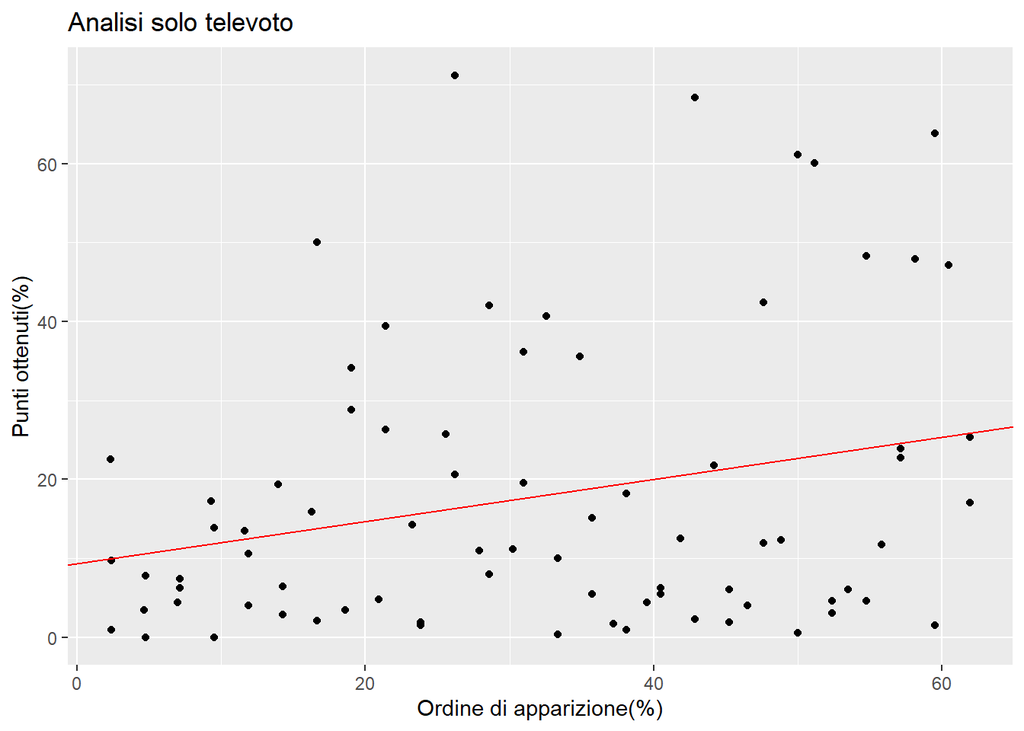

```r
ggplot(tele_votes, aes(percent.appearance,percent.voti)) +
  geom_point() +
  geom_abline(intercept = mod2$coefficients[1],
              slope = mod2$coefficients[2],
              color = "red")+
  labs(title="Analisi solo televoto",x="Ordine di apparizione(%)", y= "Punti ottenuti(%)")
```

La retta ci mostra quello che sospettavamo ma anche in questo caso è un aumento lieve

```r
r_tele = cor(tele_votes$percent.appearance, tele_votes$percent.voti,use= "complete.obs")
r_tele
```

```
## [1] 0.2595921
```

```r
r_tele^2
```

```
## [1] 0.06738805
```

Possiamo vedere che, sebbene il televoto sia leggermente piu correlato all’ordine di apparizione rispetto al voto globale, siamo ancora lontani dal considerare voti e ordine di apparizione correlati.

### Vale anche per i singoli stati?

Valutiamo la correlazione dei voti emessi dalle giurie dei singoli stati e l’ordine di comparsa dello stato votato

Uniamo ora i nostri dati con le tabelle di supporto al fine di ottenere una tabella utile ai nostri scopi

```r
state_votes=inner_join(state_votes,edition_max_votes)
temp=events_data%>%filter(event.type=="final" | event.type=="grand-final",event.year>1956)%>%
                select(event.year,Country,order.of.appearance)

state_votes=inner_join(state_votes,temp,by=c("event.year"="event.year","recipient.country"="Country"))%>%mutate(max_points=replace(max_points,event.year>=2016,12), pts.percent=100*pts/max_points)

state_votes
```

```
## # A tibble: 14,031 x 7
##    event.year awarding.country recipient.country   pts max_points
##         <dbl> <chr>            <chr>             <dbl>      <dbl>
##  1       1957 Austria          The Netherlands       6         10
##  2       1957 Austria          Luxembourg            3         10
##  3       1957 Austria          United Kingdom        1         10
##  4       1957 Belgium          The Netherlands       5         10
##  5       1957 Belgium          France                2         10
##  6       1957 Belgium          United Kingdom        1         10
##  7       1957 Belgium          Italy                 1         10
##  8       1957 Belgium          Germany               1         10
##  9       1957 Denmark          The Netherlands       3         10
## 10       1957 Denmark          Belgium               2         10
## # ... with 14,021 more rows, and 2 more variables: order.of.appearance <dbl>,
## #   pts.percent <dbl>
```

Ora raggruppiamo i dati in base allo stato votante cosi da avere i dati che ci servono su un unica riga

```r
grouped_states=state_votes%>%group_by(awarding.country)%>%nest()
grouped_states[1]
```

```
## # A tibble: 52 x 1
## # Groups:   awarding.country [52]
##    awarding.country
##    <chr>
##  1 Austria
##  2 Belgium
##  3 Denmark
##  4 France
##  5 Germany
##  6 Italy
##  7 Luxembourg
##  8 Switzerland
##  9 The Netherlands
## 10 United Kingdom
## # ... with 42 more rows
```

```r
grouped_states[[2]][1]
```

```
## [[1]]
## # A tibble: 443 x 6
##    event.year recipient.country   pts max_points order.of.appearance pts.percent
##         <dbl> <chr>             <dbl>      <dbl>               <dbl>       <dbl>
##  1       1957 The Netherlands       6         10                   6          60
##  2       1957 Luxembourg            3         10                   2          30
##  3       1957 United Kingdom        1         10                   3          10
##  4       1958 France                7         10                   3          70
##  5       1958 Germany               1         10                   8          10
##  6       1958 Italy                 1         10                   1          10
##  7       1958 Sweden                1         10                   5          10
##  8       1959 The Netherlands       3         10                   5          30
##  9       1959 Denmark               2         10                   2          20
## 10       1959 United Kingdom        2         10                  10          20
## # ... with 433 more rows
```

Ora che abbiamo reso il nostro dataframe piu ordinato possiamo agire su di esso e calcolare la correlazione tra voti e apparizione per ogni singolo stato con la funzione map()

```r
states_model=function(df)
{
  lm(order.of.appearance ~ pts.percent, data=df)
}

grouped_states=grouped_states%>%mutate(model=map(data,states_model))

grouped_states
```

```
## # A tibble: 52 x 3
## # Groups:   awarding.country [52]
##    awarding.country data               model
##    <chr>            <list>             <list>
##  1 Austria          <tibble [443 x 6]> <lm>
##  2 Belgium          <tibble [521 x 6]> <lm>
##  3 Denmark          <tibble [399 x 6]> <lm>
##  4 France           <tibble [525 x 6]> <lm>
##  5 Germany          <tibble [529 x 6]> <lm>
##  6 Italy            <tibble [353 x 6]> <lm>
##  7 Luxembourg       <tibble [293 x 6]> <lm>
##  8 Switzerland      <tibble [501 x 6]> <lm>
##  9 The Netherlands  <tibble [508 x 6]> <lm>
## 10 United Kingdom   <tibble [543 x 6]> <lm>
## # ... with 42 more rows
```

Decomprimiamo la tabella ed estrapoliamo R^2 per verificare se esistono stati influenzati nel loro voto

```r
grouped_states=grouped_states %>% mutate(data = map2(data, model, add_residuals))

grouped_states = grouped_states %>% mutate(glance = map(model, broom::glance))

states_dipendence=unnest(grouped_states,glance)
states_dipendence=states_dipendence%>%arrange(-r.squared)%>%select(awarding.country,r.squared)

states_dipendence
```

```
## # A tibble: 52 x 2
## # Groups:   awarding.country [52]
##    awarding.country r.squared
##    <chr>                <dbl>
##  1 Czech Republic      0.0463
##  2 Morocco             0.0441
##  3 Poland              0.0290
##  4 Azerbaijan          0.0259
##  5 Yugoslavia          0.0230
##  6 Estonia             0.0226
##  7 The Netherlands     0.0174
##  8 Ireland             0.0169
##  9 Bulgaria            0.0161
## 10 United Kingdom      0.0157
## # ... with 42 more rows
```

Come visto in precedenza siamo ancora lontani dal definire una correlazione tra voti e ordine di apparizione

Possiamo però notare che Marocco e Republica Ceca hanno valori nettamente piu alti rispetto agli altri stati

Cio è dovuto al basso numero di partecipazioni(visibile nelle tabelle mostrate all’inizio). Hanno rispettivamente partecipato 1 e 3 volte alla finale degli eurovision quindi non si hanno sufficienti dati per esprimere una correlazione.